# Predictive Model for Classification of Exercise Data

## Introduction

This is an R Markdown document for the final project of the practical machin learning course. It elaborates how random forest algorthm is used for prediction in a classification problem.

## Goal

The goal of this project is to use data from accelerometers on the belt, forearm, arm, and dumbell of 6 participants and predict if they perform the excercise correctly or incorrectly.

## Data:

The training data for this project are available here: https://d396qusza40orc.cloudfront.net/predmachlearn/pml-training.csv The test data are available here: https://d396qusza40orc.cloudfront.net/predmachlearn/pml-testing.csv

The data for this project come from this source: http://web.archive.org/web/20161224072740/http:/groupware.les.inf.puc-rio.br/har.

Import libraries:

```r
library(randomForest)
library(caret) #for confusionMatrix
```

Read downloaded files:

```r
Train = read.csv("pml-training.csv")
Test = read.csv("pml-testing.csv")
```

Length of training and test data:

```r
nrow(Train)
```

```
## [1] 19622
```

```r
nrow (Test)
```

```
## [1] 20
```

After exploring the data, it is found that there are several columns that include many NA data. find columns with NA values and remove them. Also remove the first 7 columns which won’t be used in the prediction. column names that include words Kurtosis, skewness, max, min, amplitude whcih are a function of other columns are also removed.

```r
TrainM <- Train[,-c(1:7,which(colSums(is.na(Train))>1))]
TestM <- Test[,-c(1:7,which(colSums(is.na(Test))>1))]

TrainM <- TrainM[,-which(grepl("kurtosis|skewness|max|min|amplitude",
                               colnames(TrainM)))]
```

Subsample 1000 data points from the trainM data to find some of the model parameters (to save time).

```r
Training <- TrainM[sample(nrow(TrainM),1000),]
```

First perform cross validation with 5 folds to find optimal number of variables (mtry):

```r
rf.cvfit <- rfcv(Training[,-ncol(Training)], Training[,"classe"], cv.fold = 5)
rf.cvfit$error.cv
```

```
##    52    26    13     6     3     1
## 0.112 0.105 0.117 0.143 0.256 0.586
```

Perform a general random forest on the suset data and plot error as a function of number of trees to figure out how many trees to use:

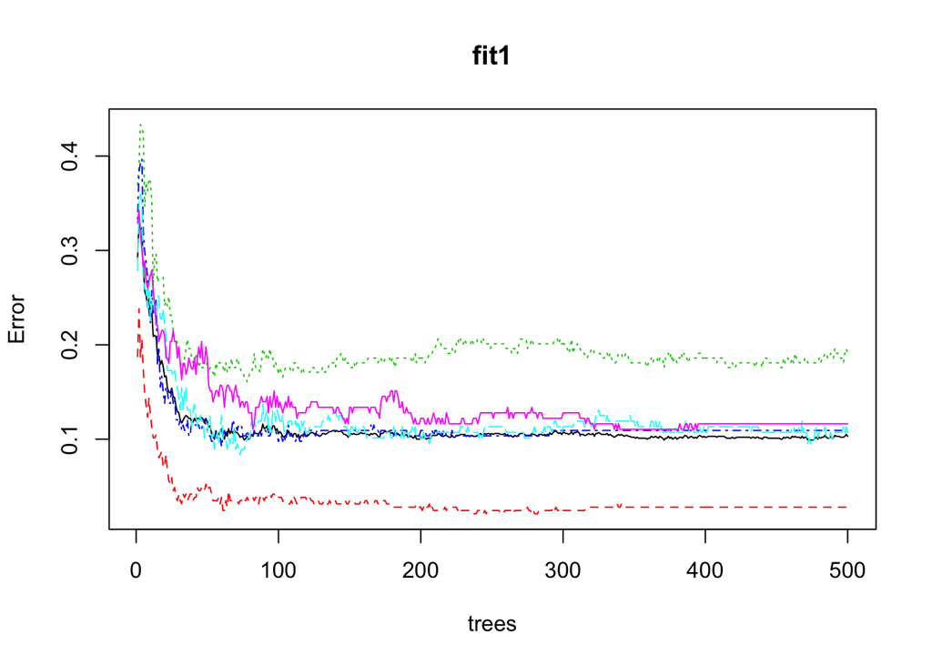

```r
fit1 <- randomForest(classe ~ ., data = Training, importance= T, mtry = 13)
plot(fit1)
```

Use 80 trees in the random forest model. Fit the model to 80% of training data and test it on the remainder 20% data:

```r
Training80_ind =sample(nrow(TrainM),round(.8*nrow(TrainM),0))
training80 <-TrainM[Training80_ind,]
testing80 <- TrainM[-Training80_ind,]
RFfit <- randomForest(x = training80[,-ncol(training80)],y = training80[,ncol(training80)], importance= T, mtry = 13, ntree =80)
```

Predict on the left-out 20% of the data

```r
prediction <-predict(RFfit, newdata = testing80)
confusionMatrix(prediction, testing80$classe)
```

```
## Confusion Matrix and Statistics
##
##           Reference
## Prediction    A    B    C    D    E
##          A 1103    3    0    0    0
##          B    0  759    4    0    0
##          C    0    0  711    7    0
##          D    0    0    0  617    2
##          E    0    0    0    0  718
##
## Overall Statistics
##
##                Accuracy : 0.9959
##                  95% CI : (0.9934, 0.9977)
##     No Information Rate : 0.2811
##     P-Value [Acc > NIR] : < 2.2e-16
##
##                   Kappa : 0.9948
##  Mcnemar's Test P-Value : NA
##
## Statistics by Class:
##
##                      Class: A Class: B Class: C Class: D Class: E
## Sensitivity            1.0000   0.9961   0.9944   0.9888   0.9972
## Specificity            0.9989   0.9987   0.9978   0.9994   1.0000
## Pos Pred Value         0.9973   0.9948   0.9903   0.9968   1.0000
## Neg Pred Value         1.0000   0.9991   0.9988   0.9979   0.9994
## Prevalence             0.2811   0.1942   0.1822   0.1590   0.1835
## Detection Rate         0.2811   0.1934   0.1812   0.1572   0.1830
## Detection Prevalence   0.2819   0.1944   0.1830   0.1577   0.1830
## Balanced Accuracy      0.9995   0.9974   0.9961   0.9941   0.9986
```

Prediction on the actual test set for the quiz (100% accuracy):

```r
FinalPrediction <-predict(RFfit, newdata = TestM)
FinalPrediction
```

```
##  1  2  3  4  5  6  7  8  9 10 11 12 13 14 15 16 17 18 19 20
##  B  A  B  A  A  E  D  B  A  A  B  C  B  A  E  E  A  B  B  B
## Levels: A B C D E
```